# Clasificación de imágenes de letras

Aprendizaje Estadístico

Laura Pérez - Gabriel Raby

14 de Octubre 2021

# Introducción

A partir de un **conjunto de datos de imágenes**, se buscará aplicar técnicas de aprendizaje estadístico para **clasificarlas según un objetivo** o criterio específico.

## Dataset

Conjunto de 86 imágenes de letras manuscritas

- **Formato**: imágenes en formato JPG o PNG
- **Tamaño**: 200 x 200 px

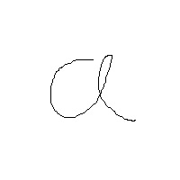

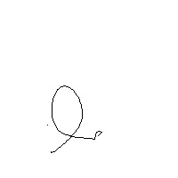

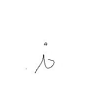

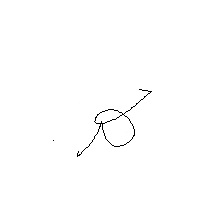

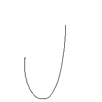

## Objetivo

Para simplificar la tarea de clasificacion en lugar de clasificacion multi-clase en primera instancia se decidio defininir un objetivo de clasificacion binaria. Se pretende generar un modelo estadístico que pueda clasificar las imágenes de letras según el siguiente criterio:

- Criterio positivo: **es** una *letra a*
- Criterio negativo: **no es** una *letra a*

## Técnicas

Se utilizarán las siguientes técnicas de aprendizaje estadístico:

- **Regresión logística**
- **Clasificación K-NN**

## Metodología de Trabajo

El proceso de trabajo será el siguiente:

- **Pre-procesamiento**: el conjunto de datos será transformado de modo tal que pueda ser utilizado durante el modelado
- **Definición de modelos**: se ajustarán los modelos definidos para cada técnica con los datos de entrenamiento
- **Evaluación de modelos**: a partir de los modelos ajustados, se estimarán resultados de clasificación sobre los datos de evaluación
- **Conclusión**: se compararán los resultados de clasificación de ambas técnicas

# Preprocesamiento

En esta etapa del flujo de trabajo se transformará el conjunto de datos de modo tal que pueda ser utilizado durante el modelado

## Formato de imágenes

Se utilizará la librería [**ImageR**](https://dahtah.github.io/imager/imager.html).

Esta librería utiliza el formato estándar de imágenes [**CImg**](https://cimg.eu/).

Este formato representa las imágenes como un arreglo numérico *4D* (*x*, *y*, *z*, *c*)

- **x**, **y**: dimensiones espaciales
- **z**: profundidad o tiempo (en secuencia de imágenes)
- **c**: color

## Carga de datos

Se cargan las 86 imágenes en una lista

```r
imgList <- load.dir("./letras")

glimpse(imgList[1:5])
```

```
## List of 5
##  $ a (1).jpg  : 'cimg' num [1:200, 1:200, 1, 1:3] 1 1 1 1 1 1 1 1 1 1 ...
##  $ a (2).jpg  : 'cimg' num [1:200, 1:200, 1, 1:3] 1 1 1 1 1 1 1 1 1 1 ...
##  $ a_1 (1).jpg: 'cimg' num [1:200, 1:200, 1, 1:3] 1 1 1 1 1 1 1 1 1 1 ...
##  $ a_1.jpg    : 'cimg' num [1:200, 1:200, 1, 1:3] 1 1 1 1 1 1 1 1 1 1 ...
##  $ a_10.jpg   : 'cimg' num [1:200, 1:200, 1, 1:3] 1 1 1 1 1 1 1 1 1 1 ...
##  - attr(*, "class")= chr [1:2] "imlist" "list"
```

## Transformaciones (1 de 2)

Se realizan las siguientes transformaciones a la lista de imágenes:

- uniformar y reducir tamaño de imgs – [100,100,z,c]
- eliminar canales de color (grayscale) – [x,y,1,1]

```r
imgList %<>%
  map(resize, 100, 100) %>%
  map(function(x) as.cimg(as.vector(round(x, digits = 0)))) %>%
  map(grayscale)
```

## Transformaciones (2 de 2)

Se crea matriz de imágenes adecuada para los modelos:

- generar tags de letras a partir de nombres de archivos
- armar matriz de trabajo [img, v1, …, v_i, … , v_(x*y)]

```r
# fc para leer tags a partir de los nombres de archivos
getBinaryLabel <- function(input) {
  ret <- str_split(input, "/")
  ifelse(str_sub(ret[[1]][length(ret[[1]])], 1, 1) == "a", 1, 2 )
}

binLabels <- names(imgList) %>% map(getBinaryLabel)

#matriz de imágenes en formato adecuado para modelos
imgMatrix <- as_tibble(cbind(unlist(binLabels),
                             matrix(unlist(imgList),
                                    nrow=length(imgList), byrow=TRUE)))

imgMatrix <- rename(imgMatrix, letra = V1) %>%
  mutate(letra = if_else(letra==1, "aes", "noaes"),
         letra = factor(letra, levels = c("aes", "noaes")))

glimpse(imgMatrix[1:5, 1:10])
```

```
## Rows: 5
## Columns: 10
## $ letra <fct> aes, aes, aes, aes, aes
## $ V2    <dbl> 1, 1, 1, 1, 1
## $ V3    <dbl> 1, 1, 1, 1, 1
## $ V4    <dbl> 1, 1, 1, 1, 1
## $ V5    <dbl> 1, 1, 1, 1, 1
## $ V6    <dbl> 1, 1, 1, 1, 1
## $ V7    <dbl> 1, 1, 1, 1, 1
## $ V8    <dbl> 1, 1, 1, 1, 1
## $ V9    <dbl> 1, 1, 1, 1, 1
## $ V10   <dbl> 1, 1, 1, 1, 1
```

# Modelado

Durante esta etapa se ajustarán los modelos definidos para cada técnica con los datos de entrenamiento

## Tidymodels

Este framework incluye un conjunto de librerías para modelado y machine learning, y permitirá definir y evaluar los modelos previstos.

## Partición de observaciones

Se divirá el conjunto de imágenes en un conjunto de entrenamiento y otro de evaluación en una proporción de 70 a 30

```r
set.seed(4096)

#se dividen los datos en entrenamiento y prueba
letras_split <- initial_split(imgMatrix,
                                prop = 0.70,
                                strata = letra)

letras_train <- training(letras_split)
letras_test <- testing(letras_split)

# nro de filas en los datos de entrenamiento y prueba
nrow(letras_train);nrow(letras_test)
```

```
## [1] 59
```

```
## [1] 27
```

## Definición y Ajuste del modelo: Regresión Logística (1 de 2)

Usando funciones de *tidymodels* se define el modelo de regresión logística

1. Se llama la función `logistic_reg()` correspondiente al modelo de regresión logística.
2. Se define el *motor* de modelado con la función `set_engine()` ; en este caso, se agrega **glm** ya que la regresión logística se incluye dentro de los GLM.
3. Se define el modo en el que funcionará el modelo con la función `set_mode()`, en este caso es una clasificación.
4. Se usa la función `fit()` para ajustar el modelo a partir de los datos de entrenamiento.

## Definición y Ajuste del modelo: Regresión Logística (2 de 2)

```r
fitted_logistic_model <- logistic_reg() %>%
  set_engine("glm") %>%
  set_mode("classification") %>%
  fit(letra ~., data = letras_train)

tidy(fitted_logistic_model, exponentiate=TRUE)
```

```
## # A tibble: 10,001 × 5
##    term          estimate std.error  statistic p.value
##    <chr>            <dbl>     <dbl>      <dbl>   <dbl>
##  1 (Intercept)  4.34e-266 12882145. -0.0000474    1.00
##  2 V2          NA               NA  NA           NA
##  3 V3          NA               NA  NA           NA
##  4 V4          NA               NA  NA           NA
##  5 V5          NA               NA  NA           NA
##  6 V6          NA               NA  NA           NA
##  7 V7          NA               NA  NA           NA
##  8 V8          NA               NA  NA           NA
##  9 V9          NA               NA  NA           NA
## 10 V10         NA               NA  NA           NA
## # … with 9,991 more rows
```

## Predicción del modelo: Regresión Logística

```r
pred_class <- predict(fitted_logistic_model,
                      new_data = letras_test,
                      type = "class")

pred_proba <- predict(fitted_logistic_model,
                      new_data = letras_test,
                      type = "prob")

letras_results <- letras_test %>%
  select(letra) %>%
  bind_cols(pred_class, pred_proba)

letras_results[1:5, ]
```

```
## # A tibble: 5 × 4
##   letra .pred_class .pred_aes .pred_noaes
##   <fct> <fct>           <dbl>       <dbl>
## 1 aes   noaes        2.90e-12        1.00
## 2 aes   noaes        2.90e-12        1.00
## 3 aes   noaes        2.90e-12        1.00
## 4 aes   noaes        2.90e-12        1.00
## 5 aes   noaes        2.90e-12        1.00
```

## Evaluación del modelo: Regresión Logística (1 de 2)

Se presenta matriz de confusión

```r
conf_mat(letras_results, truth = letra,
         estimate = .pred_class)
```

```
##           Truth
## Prediction aes noaes
##      aes     2     3
##      noaes   6    16
```

## Evaluación del modelo: Regresión Logística (2 de 2)

Métricas de evaluación: Accuracy y Sensibilidad

```r
accuracy(letras_results, truth = letra,
         estimate = .pred_class)
```

```
## # A tibble: 1 × 3
##   .metric  .estimator .estimate
##   <chr>    <chr>          <dbl>
## 1 accuracy binary         0.667
```

```r
sens(letras_results, truth = letra,
         estimate = .pred_class)
```

```
## # A tibble: 1 × 3
##   .metric .estimator .estimate
##   <chr>   <chr>          <dbl>
## 1 sens    binary          0.25
```

## Definición y ajuste del modelo: Clasificación K-NN (1 de 2)

También se utilizan funciones de *tidymodels* para realizar una clasificación K-NN

1. Se llama la función `nearest_neighbor()` para definir un modelo que usa las K observaciones más similares del conjunto de entrenamiento para predecir nuevas muestras.
2. Se define el *motor* de modelado con la función `set_engine()` ; en este caso, se utiliza **kknn**.
3. Se define el modo en el que funcionará el modelo con la función `set_mode()`, en este caso es una clasificación.
4. Se usa la función `fit()` para ajustar el modelo a partir de los datos de entrenamiento.

## Definición y ajuste del modelo: Clasificación K-NN (2 de 2)

```r
fitted_knn_model <- nearest_neighbor(neighbors = 2) %>%
  set_engine("kknn") %>%
  set_mode("classification") %>%
  fit(letra ~., data = letras_train)

fitted_knn_model
```

```
## parsnip model object
##
## Fit time:  7.4s
##
## Call:
## kknn::train.kknn(formula = letra ~ ., data = data, ks = min_rows(2,     data, 5))
##
## Type of response variable: nominal
## Minimal misclassification: 0.7118644
## Best kernel: optimal
## Best k: 2
```

## Predicción del modelo: Clasificación K-NN

```r
pred_class <- predict(fitted_knn_model,
                      new_data = letras_test,
                      type = "class")

pred_proba <- predict(fitted_knn_model,
                      new_data = letras_test,
                      type = "prob")

letras_results <- letras_test %>%
  select(letra) %>%
  bind_cols(pred_class, pred_proba)

letras_results[1:5, ]
```

```
## # A tibble: 5 × 4
##   letra .pred_class .pred_aes .pred_noaes
##   <fct> <fct>           <dbl>       <dbl>
## 1 aes   aes             1           0
## 2 aes   aes             1           0
## 3 aes   noaes           0.153       0.847
## 4 aes   aes             1           0
## 5 aes   aes             1           0
```

## Evaluación del modelo: Clasificación K-NN (1 de 2)

Se presenta matriz de confusión

```r
conf_mat(letras_results, truth = letra,
         estimate = .pred_class)
```

```
##           Truth
## Prediction aes noaes
##      aes     7    17
##      noaes   1     2
```

## Evaluación del modelo: Clasificación K-NN (2 de 2)

Métricas de evaluación: Accuracy y Sensibilidad

```r
accuracy(letras_results, truth = letra,
         estimate = .pred_class)
```

```
## # A tibble: 1 × 3
##   .metric  .estimator .estimate
##   <chr>    <chr>          <dbl>
## 1 accuracy binary         0.333
```

```r
sens(letras_results, truth = letra,
         estimate = .pred_class)
```

```
## # A tibble: 1 × 3
##   .metric .estimator .estimate
##   <chr>   <chr>          <dbl>
## 1 sens    binary         0.875
```

# Conclusiones

## Conclusiones (3 de 3)

Otras consideraciones finales incluyen:

- Pruebas preliminares en **K-NN multi-clase** (es decir, todas las posibles letras) arroja similar sesgo del modelo hacia la clase mas numerosa (es decir, letra a).
- Pruebas con **Support Vector Machines (SVM)** no fueron concluidas por error arrojado por la función ksvm() durante el ajuste. Según nuestro entendimiento puede haber alguna incompatibilidad con el vector de pixeles 0s y 1s. Una alternativa a probar como trabajo futuro es con un vector con otro formato.
- Otra pista a explorar en trabajo futuro es aumentar el conjunto de datos inicial con imágenes sintéticas. Estas pueden ser creadas automáticamente aplicando *perturbaciones* tales como rotación o difuminación.